# Visualization with Python

# `matplotlib`

```python
import numpy as np
import pandas as pd
import matplotlib.pyplot as plt
import matplotlib

matplotlib.style.use('ggplot')
%matplotlib inline
```

## Matplotlib basic plotting

A MATLAB-like plotting framework: [`pyplot`](https://matplotlib.org/api/pyplot_api.html).

Also known as the "state-machine environment" because we can call methods of a global state machine and they will affect the appropiate objects.

Matplotlib tiene 2 formas de trabajar

- State machine envirotment Es la forma mas facil de trabajar
- Mediante objetos

### Lines

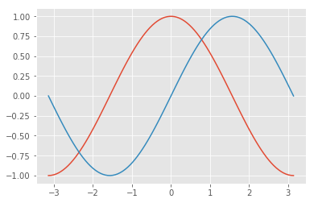

```python
X = np.linspace(-np.pi, np.pi, 100)
C,S = np.cos(X), np.sin(X)

plt.plot(X,C)
plt.plot(X,S)

plt.show()
```

#### Exercise

Plot the logistic function

$$f(x) = \frac{e^x}{1 + e^x}$$

Between -7 and 7

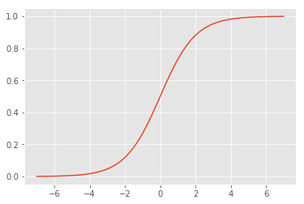

```python
n = 100

X = np.linspace(-7, 7, n)
Y = np.e ** X / (1 + np.e ** X)

plt.plot(X, Y)
plt.show()
```

### Scatter plots

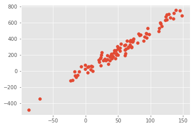

```python
true_theta_0 = 2
true_theta_1 = 5

X = (np.random.randn(100) + 1) * 50
jitter = 50 * np.random.randn(100)
Y = true_theta_0 + true_theta_1 * X
Y_randomized = Y + jitter

plt.scatter (X, Y_randomized)
plt.show()
```

```python
def generate_points(true_theta_0 = 2, true_theta_1 = 5):

    X = (np.random.randn(100) + 1) * 50
    jitter = 50 * np.random.randn(100)
    Y = true_theta_0 + true_theta_1 * X
    Y_randomized = Y + jitter

    return X, Y_randomized
```

This is what happens if you make a line plot of unsorted data:

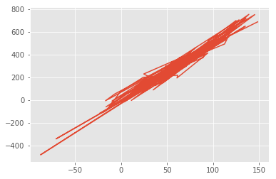

```python
plt.plot(X,Y_randomized)
```

### Bar plots

Do not confuse with histograms. Histogramas es para variables continuas y los Bar Plot para variables discretas

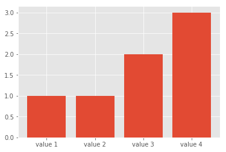

```python
X=[1,1,2,3]
Y=["value 1","value 2","value 3","value 4"]

plt.bar(range(len(X)), X)          # Asociamos el rango a los valores
plt.xticks(np.arange(len(X)), Y)   # Asociamos las etiquetas a los valores
plt.show()
```

## The object-oriented interface

Essential for finer control.

The recommended procedure is to use pyplot to create figures and the object-oriented interface for plotting.

We need to know the somewhat confusing [matplotlib terminology](http://matplotlib.org/faq/usage_faq.html#parts-of-a-figure)

[figure not shown]

#### Figure

A whole figure which may contain several Axes. It communicates with the `Canvas` for us.

Figura -> Paneles o Axes -> Axis

#### Axes vs Axis

An `Axes` (yes, it looks like a plural noun but it's not, necessarily) is a single panel of a figure. An `Axes` contains generally 2, but sometimes 3, `Axis`. It is the object type we'll spend most time interacting with.

`Axis` objects represent the lines in the x and y (and z in the case of 3D plots) dimensions. With them you can control ticks and ticklabels.

#### Artists

There are two types of Artists: primitives and containers. The primitives represent the standard graphical objects we want to paint onto our canvas: Line2D, Rectangle, Text, AxesImage, etc., and the containers are places to put them (Axis, Axes and Figure).

https://matplotlib.org/users/artists.html

### Interlude: the recommended interface for our plotting functions

From [the matplotlib FAQ](http://matplotlib.org/faq/usage_faq.html):

```
def my_plotter(ax, data1, data2, param_dict):
    """
    A helper function to make a graph

    Parameters
    ----------
    ax : Axes
        The axes to draw to

    data1 : array
       The x data

    data2 : array
       The y data

    param_dict : dict
       Dictionary of kwargs to pass to ax.plot

    Returns
    -------
    out : list
        list of artists added
    """
    out = ax.plot(data1, data2, **param_dict)
    return out
```

## `add_axes()`, `add_subplot`, and `subplots()`

We can add Axes to a Figure by calling its add_axes method.

A subplot is just an Axes that we place within an imaginary grid.

For even finer control we can use [GridSpec](http://matplotlib.org/api/gridspec_api.html)

### `add_axes()`

See https://matplotlib.org/users/artists.html

Total flexibility in placing the Axes: we specify `[left, bottom, width, height]` in 0-1 relative figure coordinates.

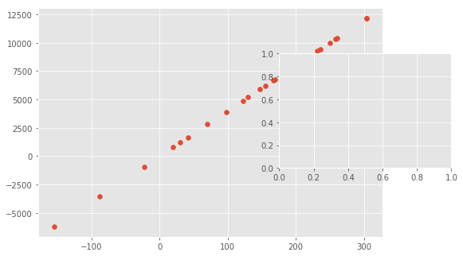

```python
X2 = np.random.randn(25) * 100 + 100
Y2 = 2 * X2 * 20

myfigure = plt.figure()

myaxes = myfigure.add_axes([0,0,1,1])

myaxes.scatter (X2, Y2)

my_second_axes = myfigure.add_axes([0.7,0.3,0.5,0.5])
```

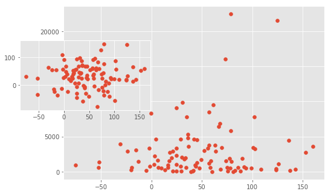

```python
X, Y = generate_points(20, 0.2)     # Es un array X corresponde al numero 20 e Y al 0.2

figure = plt.figure(figsize=(10,8))
axes = figure.add_axes([0.2,0.4,0.6,0.5])
axes.scatter(X, Y ** 2)

axes2 = figure.add_axes([0.1,0.6,0.3,0.2])
axes2.scatter(X, Y)

plt.show()
```

### Subplots

We can add them with either `figure.add_subplot()` or create a figure with its subplots directly by calling `plt.subplots()`

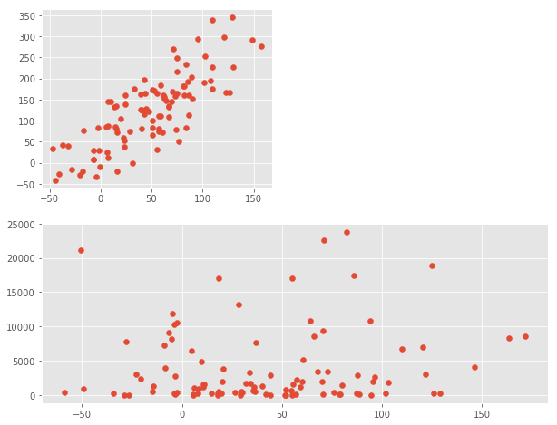

```python
X1, Y1 = generate_points(50, 1.5)
X2, Y2 = generate_points(20, 0.2)
Y2_square = Y2 ** 2

figure = plt.figure(figsize=(10,8))

subplot_1 = figure.add_subplot(2,2,1)
subplot_1.scatter(X1, Y1)

subplot_2 = figure.add_subplot(2,1,2)
subplot_2.scatter(X2, Y2_square)

plt.show()
```

### `figure.subplots()`

```
<class 'numpy.ndarray'> (2, 2)
```

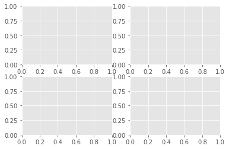

```python
figure, axes = plt.subplots(2,2)
print(type(axes), axes.shape)      # Se puede ver que son arrays 2 x 2
```

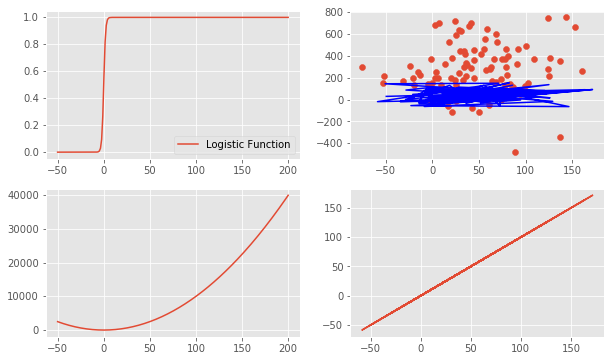

```python
figure, axeses = plt.subplots(2,2)

X_2 = np.linspace(-50, 200, 200)
Y_2 = 1 / (1 + np.exp(-X_2))

axeses[0,0].plot(X_2, Y_2)
axeses[0,1].scatter(X, Y_randomized)
axeses[0,1].plot(X2, Y2, c='blue')
axeses[1,0].plot(X_2, X_2 ** 2)
axeses[1,1].plot(X2, X2)

figure.set_size_inches(10,6)
axeses[0,0].legend(['Logistic Function'])
```

### Sharing axis

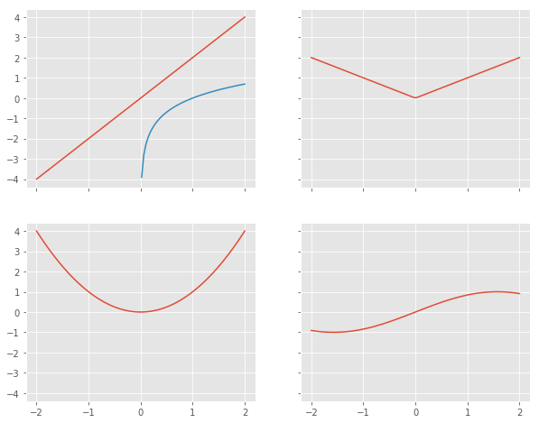

```python
X = np.linspace(-2, 2, 100)

figure, axes_array = plt.subplots(2,2, sharex=True, sharey=True)
figure.set_size_inches(10,8)       # ancho y alto de las axis

# Linear and Log
axes_array[0,0].plot(X, 2*X)
axes_array[0,0].plot(X, np.log(X))

# Abs
axes_array[0,1].plot(X, np.abs(X))

# Square
axes_array[1,0].plot(X, X ** 2)

# Sin
axes_array[1,1].plot(X, np.sin(X))

plt.show()
```

## `fill_between`

We can fill areas of the plot with solid color

The syntax is

```
plt.fill_between(X, Y1, Y2)
```

Where Y1 and Y2 are either `np.array`s or scalar values.

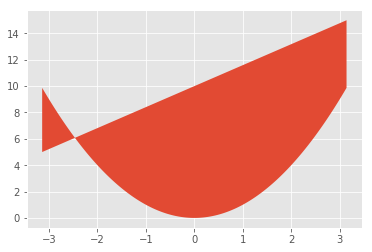

```python
n=256
X = np.linspace(-np.pi,np.pi,n)

Y1 = np.linspace(5,15,n)
Y2 = X ** 2

plt.fill_between(X, Y1, X ** 2)

plt.show()
```

## `fill_between`(`where=`)

We can fill areas of the plot with solid color differently in different parts of the graph.

The syntax is

```
plt.fill_between(X, Y1, Y2, where=boolean_array)
```

Where Y1 and Y2 are either `np.array`s or scalar values, and boolean_array can be constructed from X, from Y, or from whatever you want.

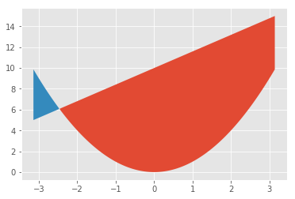

```python
n=256
X = np.linspace(-np.pi,np.pi,n)

Y1 = np.linspace(5,15,n)
Y2 = X ** 2

plt.fill_between(X, Y1, X ** 2, where=Y1 > Y2)
plt.fill_between(X, Y1, X ** 2, where=Y1 < Y2)

plt.show()
```

#### Exercise:

Given this code:

```
n = 256
X = np.linspace(-np.pi,np.pi,n,endpoint=True)
Y = np.sin(2*X)

plt.plot (X, Y+1, color='blue', alpha=1.00)
plt.plot (X, Y-1, color='blue', alpha=1.00)
plt.show()
```

Reproduce this plot:

[figure not shown]

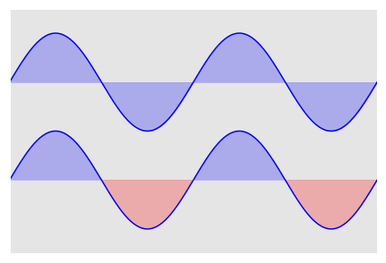

```python
n = 256
X = np.linspace(-np.pi,np.pi,n,endpoint=True)
Y = np.sin(2*X)

plt.axes([0.025,0.025,0.95,0.95])

plt.plot (X, Y+1, color='blue', alpha=1.00)
plt.fill_between(X, 1, Y+1, color='blue', alpha=.25)

plt.plot (X, Y-1, color='blue', alpha=1.00)
plt.fill_between(X, -1, Y-1, (Y-1) > -1, color='blue', alpha=.25)
plt.fill_between(X, -1, Y-1, (Y-1) < -1, color='red',  alpha=.25)

plt.xlim(-np.pi,np.pi), plt.xticks([])
plt.ylim(-2.5,2.5), plt.yticks([])

plt.show()
```

## Line properties

### Color

See https://matplotlib.org/users/colormaps.html

[figure not shown]

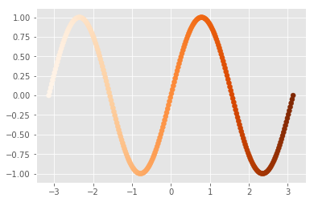

```python
from matplotlib import cm

cmap = cm.get_cmap('Oranges')
plt.scatter(X,Y, c=X, cmap=cmap)
```

#### Exercise

Given this code, try to reproduce this graphic taking care of marker size, color and transparency.

```
n = 1024
X = np.random.normal(0,1,n)
Y = np.random.normal(0,1,n)

plt.scatter(X,Y)
plt.show()
```

[figure not shown]

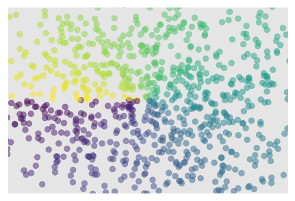

```python
n = 1024
X = np.random.normal(0,1,n)
Y = np.random.normal(0,1,n)
T = np.arctan2(Y,X)

plt.axes([0.025,0.025,0.95,0.95])
plt.scatter(X,Y, s=75, c=T, alpha=.5)

plt.xlim(-1.5,1.5), plt.xticks([])
plt.ylim(-1.5,1.5), plt.yticks([])

plt.show()
```

### Markers and linestyles

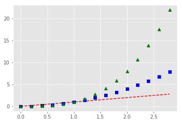

```python
figure, axes = plt.subplots(1,1)


X = np.arange(0, 3, .2)
Y1 = X
Y2 = X ** 2
Y3 = X ** 3

axes.plot(X, Y1, 'r--')
axes.plot(X, Y2, 'bs')
axes.plot(X, Y3, 'g^')

plt.show()
```

## Other attributes

http://nbviewer.jupyter.org/github/WeatherGod/AnatomyOfMatplotlib/blob/master/AnatomyOfMatplotlib-Part3-HowToSpeakMPL.ipynb

### Histograms

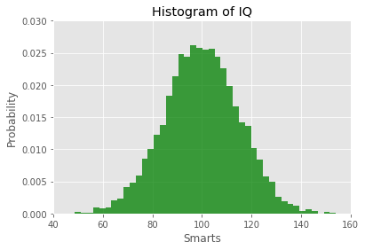

```python
mu, sigma = 100, 15
x = mu + sigma * np.random.randn(10000)

# the histogram of the data
n, bins, patches = plt.hist(x, 50, normed=1, facecolor='g', alpha=0.75)

plt.xlabel('Smarts')
plt.ylabel('Probability')
plt.title('Histogram of IQ')
plt.axis([40, 160, 0, 0.03])
plt.grid(True)
plt.show()
```

## Text and Math: $\LaTeX$

$\LaTeX$ is "a high-quality typesetting system; it includes features designed for the production of technical and scientific documentation. LaTeX is the de facto standard for the communication and publication of scientific documents" ([$LaTeX$ project website](https://www.latex-project.org/)).

It's widely used for writing mathematical equations that need to be rendered accurately.

We can use it in pretty much any place we need to use text.

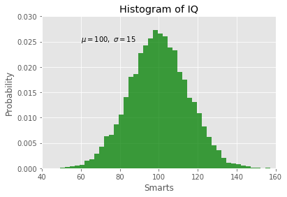

```python
mu, sigma = 100, 15
x = mu + sigma * np.random.randn(10000)

# the histogram of the data
n, bins, patches = plt.hist(x, 50, normed=1, facecolor='g', alpha=0.75)

plt.xlabel('Smarts')
plt.ylabel('Probability')
plt.title('Histogram of IQ')
plt.text(60, .025, r'$\mu=100,\ \sigma=15$')
plt.axis([40, 160, 0, 0.03])
plt.grid(True)
plt.show()
```

## Legends

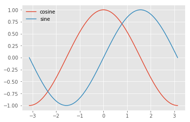

```python
X = np.linspace(-np.pi, np.pi, 100)
C,S = np.cos(X), np.sin(X)

plt.plot(X,C, label='cosine')
plt.plot(X,S, label='sine')

plt.legend(loc='best', frameon=False)

plt.show()
```

## Ticks, tick labels, limits

### Ticks

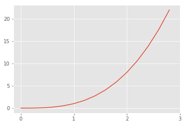

```python
figure, axes = plt.subplots(1,1)

X = np.arange(0, 3, .2)
Y = X ** 3

axes.plot(X, Y)
axes.set_xticks(range(4))   # Pinta en la parte de abajo

plt.show()
```

### Tick labels

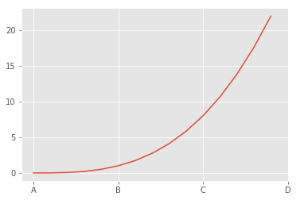

```python
figure, axes = plt.subplots(1,1)

X = np.arange(0, 3, .2)
Y = X ** 3

axes.plot(X, Y)
axes.set_xticks(range(4))
axes.set_xticklabels(list('ABCD'))  # Ahora pone etiquetas

plt.show()
```

### Limits

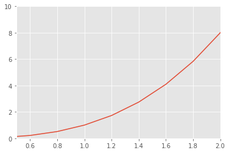

```python
plt.plot(X, Y)

axes = plt.gca()
axes.set_xlim((0.5,2))  # Limite del ancho de la grafica
axes.set_ylim((0,10))   # Limite del alto de la grafica

plt.show()
```

# Seaborn

Seaborn is a statistical data visualization library. It's built on top of matplotlib and tries to "make a well-defined set of hard things easy" ([introduction to Seaborn](http://seaborn.pydata.org/introduction.html)).

One advantage over matplotlib is that it works natively with DataFrame objects.

https://www.datacamp.com/community/tutorials/seaborn-python-tutorial

#### Exercise:

Load the `houses.csv` file into memory as a pandas `DataFrame`. Inspect its head. Clean the column names.

```python
import pandas as pd
import seaborn as sns

df = pd.read_csv('../../../data/houses.csv', index_col=0)
df.columns = [column.strip() for column in df.columns]
df.head()
```

| index | the local selling prices in hundreds of dollars | the number of bathrooms | the area of the site in thousands of square feet | the size of the living space (1000 square feet) | number of garages | number of rooms | the number of bedrooms | the age in years | construction type | architecture type | number of fire places | selling price |
| --- | --- | --- | --- | --- | --- | --- | --- | --- | --- | --- | --- | --- |
| 1 | 4.9176 | 1.0 | 3.472 | 0.998 | 1.0 | 7 | 4 | 42 | 3 | 1 | 0 | 25.9 |
| 2 | 5.0208 | 1.0 | 3.531 | 1.500 | 2.0 | 7 | 4 | 62 | 1 | 1 | 0 | 29.5 |
| 3 | 4.5429 | 1.0 | 2.275 | 1.175 | 1.0 | 6 | 3 | 40 | 2 | 1 | 0 | 27.9 |
| 4 | 4.5573 | 1.0 | 4.050 | 1.232 | 1.0 | 6 | 3 | 54 | 4 | 1 | 0 | 25.9 |
| 5 | 5.0597 | 1.0 | 4.455 | 1.121 | 1.0 | 6 | 3 | 42 | 3 | 1 | 0 | 29.9 |

```python
short_column_names = ['local_prices', 'bathrooms', 'site_area',
                      'living_area', 'garages', 'rooms',
                      'bedrooms', 'age', 'construction_type',
                      'architecture', 'fireplaces', 'price']

df.columns = short_column_names
```

## Seaborn vs matplotlib

Seaborn genera graficas basadas en matplotlib. Tiene menos flexibilidad pero lo que hace lo hace muy bien y facil

## Distribution plots

https://seaborn.pydata.org/tutorial/distributions.html

### Scatter plots

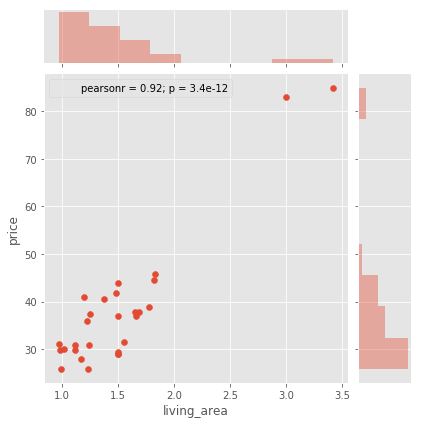

```python
sns.jointplot(data=df, x='living_area', y='price');
```

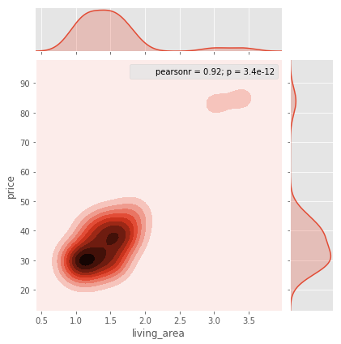

```python
sns.jointplot(data=df, x='living_area', y='price', kind='kde');
```

### Histogram

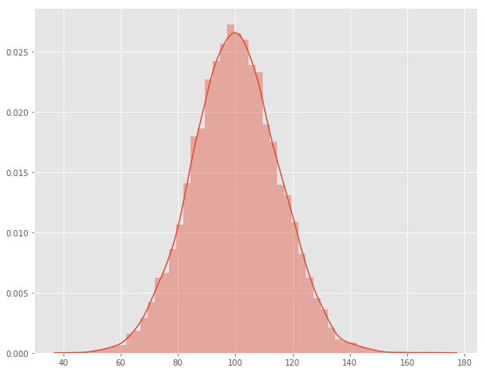

```python
plt.figure(figsize=(10,8))
X = np.random.normal(size=200)
sns.distplot(x);
```

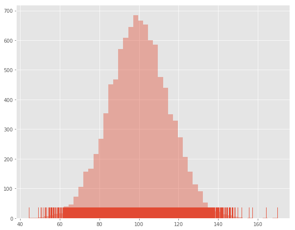

```python
plt.figure(figsize=(10,8))
X = np.random.normal(size=200)
sns.distplot(x, kde=False, rug=True);
```

More on [distplot](https://seaborn.pydata.org/generated/seaborn.distplot.html)

### Pairwise relationships

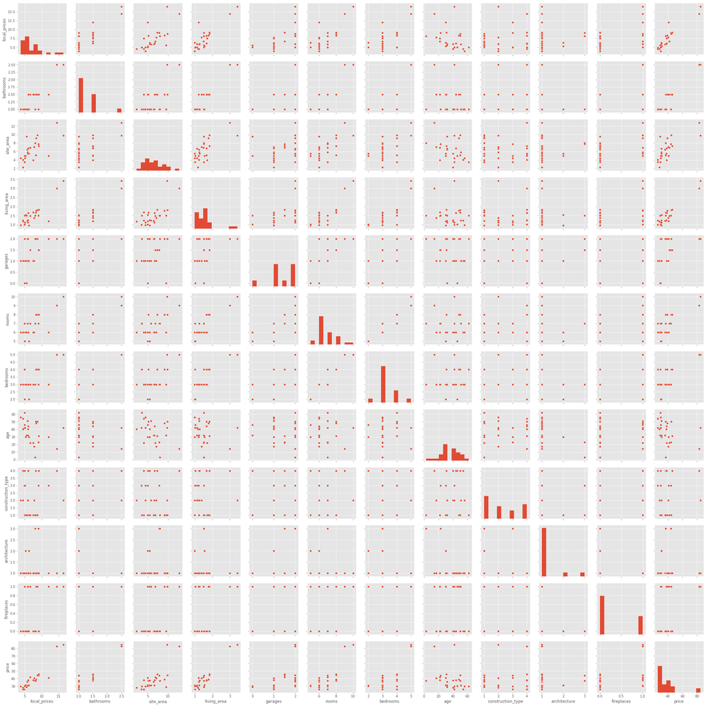

```python
plt.figure(figsize=(10,8))
sns.pairplot(df)
plt.show()
```

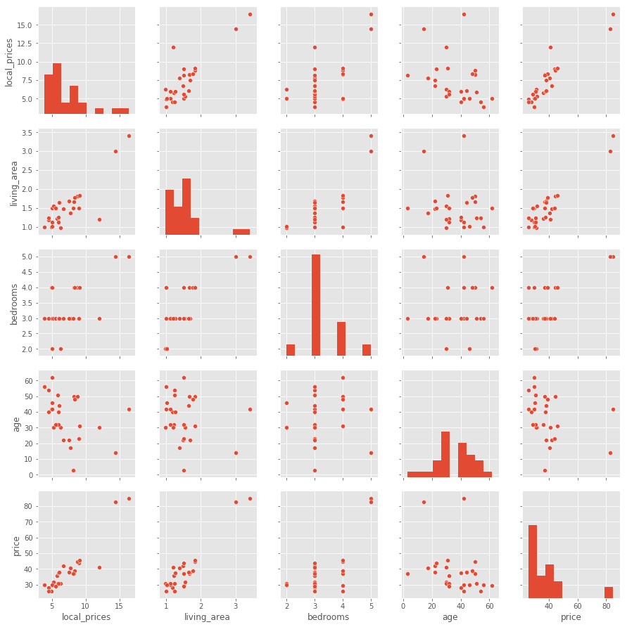

```python
plt.figure(figsize=(10,8))

sns.pairplot(df[['local_prices', 'living_area', 'bedrooms', 'age', 'price']]);
plt.show()
```

## Linear relationships

https://seaborn.pydata.org/tutorial/regression.html

### `lmplot()`

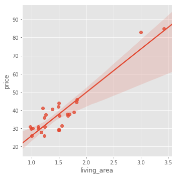

```python
sns.lmplot(data=df, x='living_area', y='price');
```

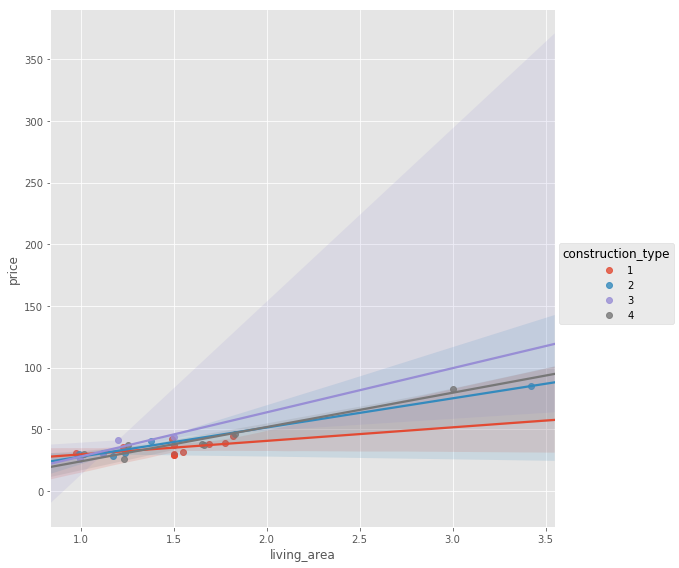

```python
sns.lmplot(data=df, x='living_area', y='price', hue='construction_type', size=8);
```

## Categorical data

https://www.kaggle.com/c/titanic/download/train.csv

https://seaborn.pydata.org/tutorial/categorical.html

```python
titanic = pd.read_csv('/home/dani/Downloads/train.csv', index_col=0)

titanic.columns = titanic.columns.str.lower()
titanic.head()
```

| PassengerId | survived | pclass | name | sex | age | sibsp | parch | ticket | fare | cabin | embarked |
| --- | --- | --- | --- | --- | --- | --- | --- | --- | --- | --- | --- |
| 1 | 0 | 3 | Braund, Mr. Owen Harris | male | 22.0 | 1 | 0 | A/5 21171 | 7.2500 | NaN | S |
| 2 | 1 | 1 | Cumings, Mrs. John Bradley (Florence Briggs Th... | female | 38.0 | 1 | 0 | PC 17599 | 71.2833 | C85 | C |
| 3 | 1 | 3 | Heikkinen, Miss. Laina | female | 26.0 | 0 | 0 | STON/O2. 3101282 | 7.9250 | NaN | S |
| 4 | 1 | 1 | Futrelle, Mrs. Jacques Heath (Lily May Peel) | female | 35.0 | 1 | 0 | 113803 | 53.1000 | C123 | S |
| 5 | 0 | 3 | Allen, Mr. William Henry | male | 35.0 | 0 | 0 | 373450 | 8.0500 | NaN | S |

### Swarm plot

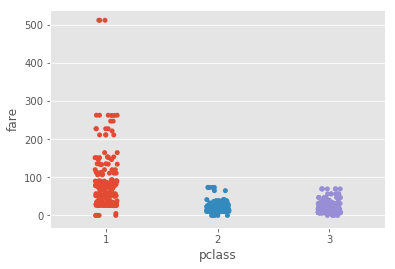

```python
sns.stripplot(data=titanic, x='pclass',y='fare', jitter=True);
```

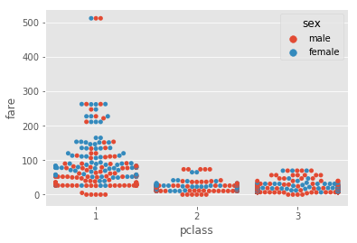

```python
sns.swarmplot(data=titanic, x='pclass',y='fare', hue='sex');
```

### Boxplot

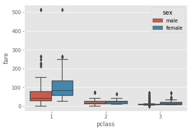

```python
sns.boxplot(data=titanic, x='pclass',y='fare', hue='sex', order=[1, 2, 3]);
```

### Barplot / countplot

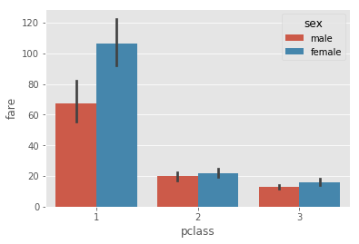

```python
sns.barplot(data=titanic, x='pclass',y='fare', hue='sex', order=[1, 2, 3]);
```

### Pointplot

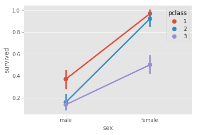

```python
sns.pointplot(x="sex", y="survived", hue="pclass", data=titanic, );
```

## Other types

### Heatmap

```python
mean_prices = df.groupby(['bathrooms', 'bedrooms'])['price'].mean()
mean_prices
```

```
bathrooms  bedrooms
1.0        2           30.500000
           3           32.223077
           4           27.700000
1.5        3           39.840000
           4           41.525000
2.5        5           83.900000
Name: price, dtype: float64
```

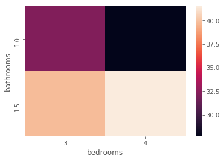

```python
sns.heatmap(mean_prices[:-1][1:].unstack());
```

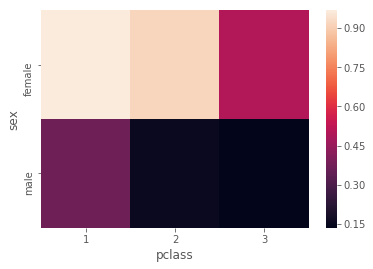

```python
survival = titanic.groupby(['sex', 'pclass'])['survived'].mean()
sns.heatmap(survival.unstack());
```

### Clustermap

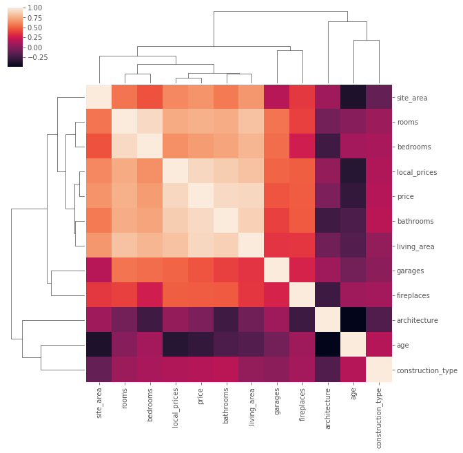

```python
sns.clustermap(df.corr());
```

# Bokeh

Bokeh "is a Python interactive visualization library that targets modern web browsers for presentation".

Two components: A Python backend and a JS frontend.

The way we use it is to declare our graphs in Python.

The Python objects will in turn generate a series of JSON objects that describe a *scenegraph*. The JS component will generate the actual visualization from that scenegraph. The upside of this is that we don't need to work with JS, but our visualizations will be browser-based and interactive

https://bokeh.pydata.org/en/latest/docs/gallery.html

https://bokeh.pydata.org/en/latest/

# Plotly

https://www.analyticsvidhya.com/blog/2017/01/beginners-guide-to-create-beautiful-interactive-data-visualizations-using-plotly-in-r-and-python/

Plotly is a multi-language tool for creating interactive visualizations. It's built on top of D3.

## Dash

"Shiny for Python"

# See Also: Vega

http://vega.github.io/

# Additional references

[Matplotlib documentation](http://matplotlib.org/contents.html)

[The matplotlib FAQ](http://matplotlib.org/faq/usage_faq.html)

[Matplotlib cheat sheet](https://s3.amazonaws.com/assets.datacamp.com/blog_assets/Python_Matplotlib_Cheat_Sheet.pdf)

[Nicolas P. Rougier's matplotlib tutorial](http://www.labri.fr/perso/nrougier/teaching/matplotlib/)

[Anatomy of Matplotlib](https://github.com/matplotlib/AnatomyOfMatplotlib)

[$\LaTeX$](https://www.latex-project.org/)

# Additional references

[Bokeh User Guide](http://bokeh.pydata.org/en/latest/docs/user_guide.html)

[Bokeh Tutorials](http://nbviewer.jupyter.org/github/bokeh/bokeh-notebooks/blob/master/index.ipynb)

[Dash](https://plot.ly/dash/)

[Dash being spotted before release](https://www.reddit.com/r/Python/comments/6imhxa/plotly_has_just_released_dash_20_a_shinylike_tool/)

[Facets](https://pair-code.github.io/facets/)

[Facets release Google research blog entry](https://research.googleblog.com/2017/07/facets-open-source-visualization-tool.html)